# Loan prediction

## 2. *==== Business Understanding ====*

Predict Loan Eligibility for Dream Housing Finance company Dream Housing Finance company deals in all kinds of home loans. They have presence across all urban, semi urban and rural areas. Customer first applies for home loan and after that company validates the customer eligibility for loan.

Company wants to automate the loan eligibility process (real time) based on customer detail provided while filling online application form. These details are Gender, Marital Status, Education, Number of Dependents, Income, Loan Amount, Credit History and others. To automate this process, they have provided a dataset to identify the customers segments that are eligible for loan amount so that they can specifically target these customers.

Train file: CSV containing the customers for whom loan eligibility is known as 'Loan_Status' Variable Description Loan_ID _____________ Unique Loan ID Gender ______________Male/ Female Married ___________ Applicant married (Y/N) Dependents __________Number of dependents Education __________Applicant Education (Graduate/ Under Graduate) Self_Employed ______Self employed (Y/N) ApplicantIncome ______Applicant income CoapplicantIncome ___Coapplicant income LoanAmount__________ Loan amount in thousands Loan_Amount_Term ____ Term of loan in months Credit_History______ credit history meets guidelines Property_Area _______ Urban/ Semi Urban/ Rural Loan_Status ____________(Target) Loan approved (Y/N) Test file: CSV containing the customer information for whom loan eligibility is to be predicted Variable Description Loan_ID Unique Loan ID Gender Male/ Female Married Applicant married (Y/N) Dependents Number of dependents Education Applicant Education (Graduate/ Under Graduate) Self_Employed Self employed (Y/N) ApplicantIncome Applicant income CoapplicantIncome Coapplicant income LoanAmount Loan amount in thousands Loan_Amount_Term Term of loan in months Credit_History credit history meets guidelines Property_Area Urban/ Semi Urban/ Rural

### Data Collection

```python
# import packages
import numpy as np
import pandas as pd
import matplotlib.pyplot as plt
import seaborn as sns
import missingno as msno
%matplotlib inline
```

```python
#  upload data by pandas
dt = pd.read_csv('train_data.csv')
ds = pd.read_csv('test_data.csv')
```

```python
# show first 5 rows at train data
dt.head()
```

|  | Loan_ID | Gender | Married | Dependents | Education | Self_Employed | ApplicantIncome | CoapplicantIncome | LoanAmount | Loan_Amount_Term | Credit_History | Property_Area | Loan_Status |
| --- | --- | --- | --- | --- | --- | --- | --- | --- | --- | --- | --- | --- | --- |
| 0 | LP001002 | Male | No | 0 | Graduate | No | 5849 | 0.0 | NaN | 360.0 | 1.0 | Urban | Y |
| 1 | LP001003 | Male | Yes | 1 | Graduate | No | 4583 | 1508.0 | 128.0 | 360.0 | 1.0 | Rural | N |
| 2 | LP001005 | Male | Yes | 0 | Graduate | Yes | 3000 | 0.0 | 66.0 | 360.0 | 1.0 | Urban | Y |
| 3 | LP001006 | Male | Yes | 0 | Not Graduate | No | 2583 | 2358.0 | 120.0 | 360.0 | 1.0 | Urban | Y |
| 4 | LP001008 | Male | No | 0 | Graduate | No | 6000 | 0.0 | 141.0 | 360.0 | 1.0 | Urban | Y |

```python
# show first 5 rows at test data
ds.head()
```

|  | Loan_ID | Gender | Married | Dependents | Education | Self_Employed | ApplicantIncome | CoapplicantIncome | LoanAmount | Loan_Amount_Term | Credit_History | Property_Area |
| --- | --- | --- | --- | --- | --- | --- | --- | --- | --- | --- | --- | --- |
| 0 | LP001015 | Male | Yes | 0 | Graduate | No | 5720 | 0 | 110.0 | 360.0 | 1.0 | Urban |
| 1 | LP001022 | Male | Yes | 1 | Graduate | No | 3076 | 1500 | 126.0 | 360.0 | 1.0 | Urban |
| 2 | LP001031 | Male | Yes | 2 | Graduate | No | 5000 | 1800 | 208.0 | 360.0 | 1.0 | Urban |
| 3 | LP001035 | Male | Yes | 2 | Graduate | No | 2340 | 2546 | 100.0 | 360.0 | NaN | Urban |
| 4 | LP001051 | Male | No | 0 | Not Graduate | No | 3276 | 0 | 78.0 | 360.0 | 1.0 | Urban |

## 3. *==== Data understanding ====*

```python
## Shape of the train data
dt.shape
```

```
(614, 13)
```

```python
## Shape of the test data
ds.shape
```

```
(367, 12)
```

```python
## Check nullity
nullity = dt.isna().sum()
nullity
```

```
Loan_ID               0
Gender               13
Married               3
Dependents           15
Education             0
Self_Employed        32
ApplicantIncome       0
CoapplicantIncome     0
LoanAmount           22
Loan_Amount_Term     14
Credit_History       50
Property_Area         0
Loan_Status           0
dtype: int64
```

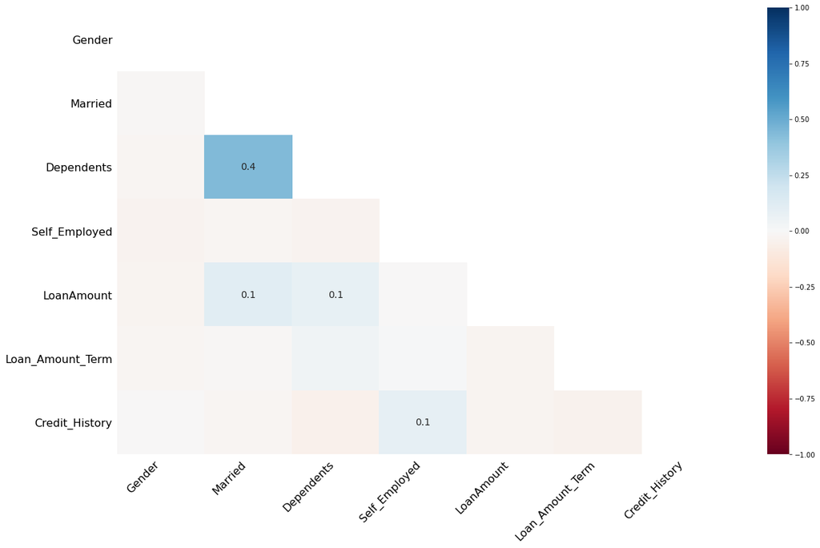

```python
# Correlations between null values
msno.heatmap(dt)
```

```python
# Check for duplicates
duplic = dt.duplicated().sum()
duplic
```

```
0
```

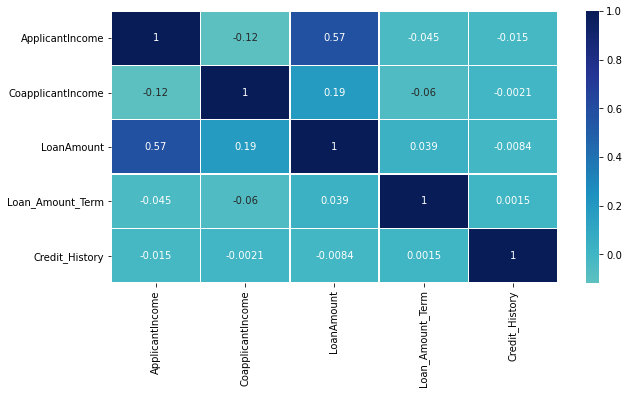

```python
## Check correlations between numerical variables
fig, ax = plt.subplots(figsize=(10,5))         # Sample figsize in inches
sns.heatmap(dt.corr(), annot=True, center=0, linewidths=.5, cmap="YlGnBu")
```

```python
## Statistics summary
dt.describe()
```

|  | ApplicantIncome | CoapplicantIncome | LoanAmount | Loan_Amount_Term | Credit_History |
| --- | --- | --- | --- | --- | --- |
| count | 614.000000 | 614.000000 | 592.000000 | 600.00000 | 564.000000 |
| mean | 5403.459283 | 1621.245798 | 146.412162 | 342.00000 | 0.842199 |
| std | 6109.041673 | 2926.248369 | 85.587325 | 65.12041 | 0.364878 |
| min | 150.000000 | 0.000000 | 9.000000 | 12.00000 | 0.000000 |
| 25% | 2877.500000 | 0.000000 | 100.000000 | 360.00000 | 1.000000 |
| 50% | 3812.500000 | 1188.500000 | 128.000000 | 360.00000 | 1.000000 |
| 75% | 5795.000000 | 2297.250000 | 168.000000 | 360.00000 | 1.000000 |
| max | 81000.000000 | 41667.000000 | 700.000000 | 480.00000 | 1.000000 |

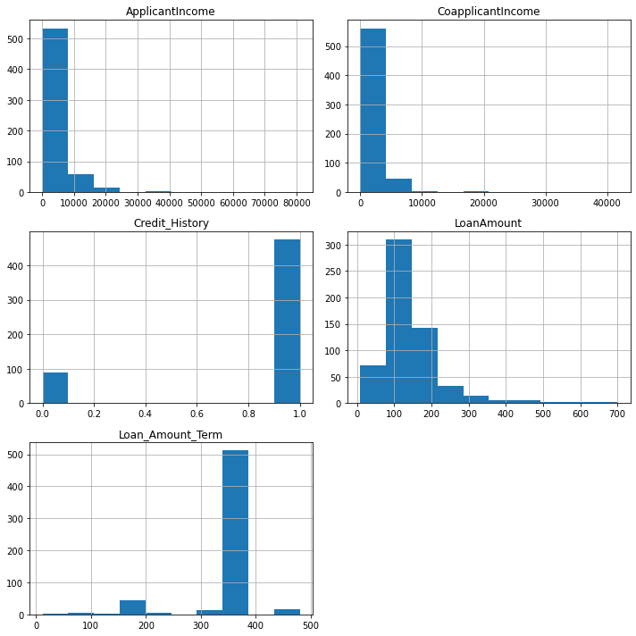

```python
dt.hist(figsize=(10, 10))
plt.tight_layout()
plt.show()
```

#### Note:

```
Our data contains Outliers
```

### Limitations:

```
1 - The Size of data is Small
2 - Data contains null values
3 - Data Contains outliers
4 - it's good to convert applicantIncome, coapplicantIncome and LoanAmountTerm to be by thousands
```

## 4. *==== Data preparation ====*

#### A. dealing with Null Values

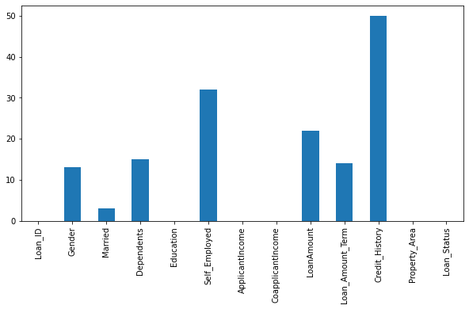

```python
nullity.plot(kind='bar',figsize=(10, 5) )
```

There are very less missing values in Gender, Married, Dependents, Credit_History and Self_Employed features so we can fill them using the mode of the features

```python
dic = ['Gender', 'Married', 'Dependents', 'Credit_History', 'Self_Employed']
dt['Gender'].fillna(dt['Gender'].mode()[0], inplace=True)
dt['Married'].fillna(dt['Married'].mode()[0], inplace=True)
dt['Dependents'].fillna(dt['Dependents'].mode()[0], inplace=True)
dt['Credit_History'].fillna(dt['Credit_History'].mode()[0], inplace=True)
dt['Self_Employed'].fillna(dt['Self_Employed'].mode()[0], inplace=True)
```

```python
## Take a look at value counts of Loan Amount Term
dt['Loan_Amount_Term'].value_counts()
```

```
360.0    512
180.0     44
480.0     15
300.0     13
84.0       4
240.0      4
120.0      3
36.0       2
60.0       2
12.0       1
Name: Loan_Amount_Term, dtype: int64
```

```python
## we can handle missing values in this variable by mode too
dt['Loan_Amount_Term'].fillna(dt['Loan_Amount_Term'].mode()[0], inplace=True)
```

Since the variable of Loan Amount contain ouliers we can't handle missing values by mean so we will handle it by variable Median

```python
dt['LoanAmount'].fillna(dt['LoanAmount'].median(), inplace=True)
```

```python
dt.isna().sum()
```

```
Loan_ID              0
Gender               0
Married              0
Dependents           0
Education            0
Self_Employed        0
ApplicantIncome      0
CoapplicantIncome    0
LoanAmount           0
Loan_Amount_Term     0
Credit_History       0
Property_Area        0
Loan_Status          0
dtype: int64
```

```python
dt.shape
```

```
(614, 13)
```

#### B. Dealing with outliers:

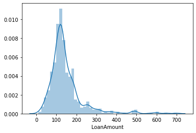

```python
sns.distplot(dt['LoanAmount'])
plt.show()
```

One way to remove the skewness is by doing the log transformation. As we take the log transformation, it does not affect the smaller values much, but reduces the larger values.

So, we get a distribution similar to normal distribution.

```python
dt['LoanAmount_log'] = np.log(dt['LoanAmount'])
```

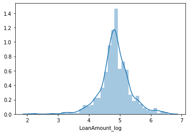

```python
sns.distplot(dt['LoanAmount_log'])
plt.show()
```

```python
dt.describe()
```

|  | ApplicantIncome | CoapplicantIncome | LoanAmount | Loan_Amount_Term | Credit_History | LoanAmount_log |
| --- | --- | --- | --- | --- | --- | --- |
| count | 614.000000 | 614.000000 | 614.000000 | 614.000000 | 614.000000 | 614.000000 |
| mean | 5403.459283 | 1621.245798 | 145.752443 | 342.410423 | 0.855049 | 4.857250 |
| std | 6109.041673 | 2926.248369 | 84.107233 | 64.428629 | 0.352339 | 0.495996 |
| min | 150.000000 | 0.000000 | 9.000000 | 12.000000 | 0.000000 | 2.197225 |
| 25% | 2877.500000 | 0.000000 | 100.250000 | 360.000000 | 1.000000 | 4.607658 |
| 50% | 3812.500000 | 1188.500000 | 128.000000 | 360.000000 | 1.000000 | 4.852030 |
| 75% | 5795.000000 | 2297.250000 | 164.750000 | 360.000000 | 1.000000 | 5.104426 |
| max | 81000.000000 | 41667.000000 | 700.000000 | 480.000000 | 1.000000 | 6.551080 |

```python
dt.columns
```

```
Index(['Loan_ID', 'Gender', 'Married', 'Dependents', 'Education',
       'Self_Employed', 'ApplicantIncome', 'CoapplicantIncome', 'LoanAmount',
       'Loan_Amount_Term', 'Credit_History', 'Property_Area', 'Loan_Status',
       'LoanAmount_log'],
      dtype='object')
```

## 5. Feature Engineering:

```
Based on the domain knowledge, we can come up with new features that might affect the target variable.
```

```python
## Total_income = ApplicantIncome + CopplicantIncome
```

```python
dt['Total_income'] = dt['ApplicantIncome'] + dt['CoapplicantIncome']
dt['Total_income'].mean()
```

```
7024.705081414722
```

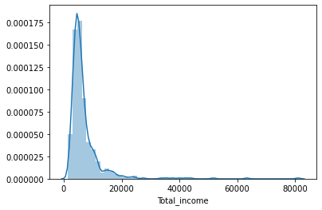

```python
sns.distplot(dt['Total_income'])
plt.show()
```

```python
dt['Total_income_log'] = np.log(dt['Total_income'])
```

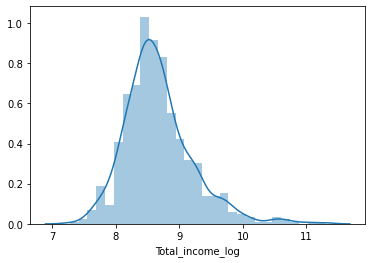

```python
sns.distplot(dt['Total_income_log'])
```

## 5. EDA (Bivariate and univariate):

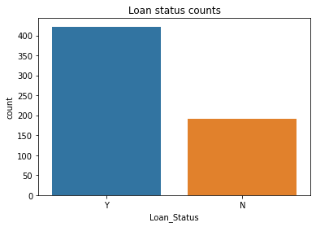

```python
## Loan Status Variable
sns.countplot(dt['Loan_Status'])
plt.title('Loan status counts')
plt.show()
```

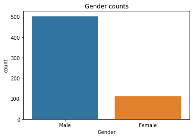

```python
sns.countplot(dt['Gender'])
plt.title('Gender counts')
plt.show()
```

```python
## Loan_Status with Gender
print(pd.crosstab(dt['Gender'],dt['Loan_Status']))
Gender = pd.crosstab(dt['Gender'],dt['Loan_Status'])
```

```
Loan_Status    N    Y
Gender
Female        37   75
Male         155  347
```

Since the loan status and Gender data not balanced we should use Ratio instead of count and use stacked bar plot

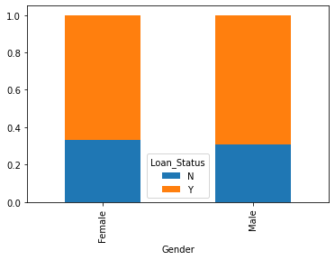

```python
Gender.div(Gender.sum(1).astype(float),axis=0).plot.bar(stacked=True)
```

Proportion of Male applicants is higher for the approved loans.

```
Loan_Status    N    Y
Married
No            79  134
Yes          113  288
```

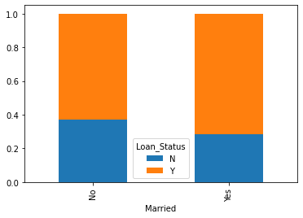

```python
## Loan_Status with Gender
print(pd.crosstab(dt['Married'],dt['Loan_Status']))
Married = pd.crosstab(dt['Married'],dt['Loan_Status'])
Married.div(Married.sum(1).astype(float),axis=0).plot.bar(stacked=True)
plt.show()
```

Proportion of Married applicants is higher for the approved loans.

```python
dt['Dependents'].value_counts()
```

```
0     360
1     102
2     101
3+     51
Name: Dependents, dtype: int64
```

```
Loan_Status    N    Y
Dependents
0            113  247
1             36   66
2             25   76
3+            18   33
```

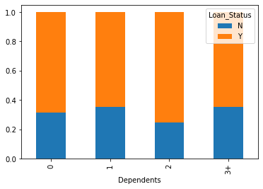

```python
print(pd.crosstab(dt['Dependents'],dt['Loan_Status']))
Dependents = pd.crosstab(dt['Dependents'],dt['Loan_Status'])
Dependents.div(Dependents.sum(1).astype(float),axis=0).plot.bar(stacked=True)
plt.show()
```

```
Loan_Status       N    Y
Credit_History
0.0              82    7
1.0             110  415
```

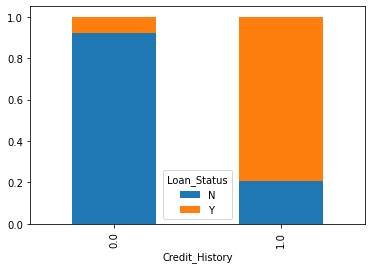

```python
print(pd.crosstab(dt['Credit_History'],dt['Loan_Status']))
Credit_History = pd.crosstab(dt['Credit_History'],dt['Loan_Status'])
Credit_History.div(Credit_History.sum(1).astype(float),axis=0).plot.bar(stacked=True)
plt.show()
```

It seems people with credit history as 1 are more likely to get their loans approved.

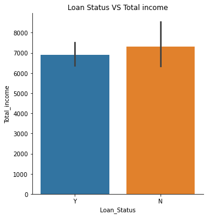

```python
sns.catplot(data=dt, kind='bar', x='Loan_Status', y='Total_income')
plt.title('Loan Status VS Total income')
plt.show()
```

### Conclusion of EDA:

[output not shown]

## 6. *==== Data modeling ====*

#### First i will prepare the Testing data

```python
## Handle missing values
ds['Gender'].fillna(ds['Gender'].mode()[0], inplace=True)
ds['Married'].fillna(ds['Married'].mode()[0], inplace=True)
ds['Dependents'].fillna(ds['Dependents'].mode()[0], inplace=True)
ds['Credit_History'].fillna(ds['Credit_History'].mode()[0], inplace=True)
ds['Self_Employed'].fillna(ds['Self_Employed'].mode()[0], inplace=True)
ds['Loan_Amount_Term'].fillna(ds['Loan_Amount_Term'].mode()[0], inplace=True)
ds['LoanAmount'].fillna(ds['LoanAmount'].median(), inplace=True)
## Handle outliers
ds['LoanAmount_log'] = np.log(ds['LoanAmount'])
## Feature Engineering
ds['Total_income'] = ds['ApplicantIncome'] + ds['CoapplicantIncome']
ds['Total_income_log'] = np.log(ds['Total_income'])
```

```python
ds.head()
```

|  | Loan_ID | Gender | Married | Dependents | Education | Self_Employed | ApplicantIncome | CoapplicantIncome | LoanAmount | Loan_Amount_Term | Credit_History | Property_Area | LoanAmount_log | Total_income | Total_income_log |
| --- | --- | --- | --- | --- | --- | --- | --- | --- | --- | --- | --- | --- | --- | --- | --- |
| 0 | LP001015 | Male | Yes | 0 | Graduate | No | 5720 | 0 | 110.0 | 360.0 | 1.0 | Urban | 4.700480 | 5720 | 8.651724 |
| 1 | LP001022 | Male | Yes | 1 | Graduate | No | 3076 | 1500 | 126.0 | 360.0 | 1.0 | Urban | 4.836282 | 4576 | 8.428581 |
| 2 | LP001031 | Male | Yes | 2 | Graduate | No | 5000 | 1800 | 208.0 | 360.0 | 1.0 | Urban | 5.337538 | 6800 | 8.824678 |
| 3 | LP001035 | Male | Yes | 2 | Graduate | No | 2340 | 2546 | 100.0 | 360.0 | 1.0 | Urban | 4.605170 | 4886 | 8.494129 |
| 4 | LP001051 | Male | No | 0 | Not Graduate | No | 3276 | 0 | 78.0 | 360.0 | 1.0 | Urban | 4.356709 | 3276 | 8.094378 |

#### Now it's time to prepare our data for modeling:

```python
## drop Loan_ID
train = dt.drop('Loan_ID', axis=1)
```

```python
## Split data to predictors and Target
X = train.drop('Loan_Status', axis=1)
y = train['Loan_Status']
```

```python
X_test = ds.drop('Loan_ID', axis=1)
```

```python
## Convert categorical Variables to dummies
X = pd.get_dummies(X)
```

```python
X_test = pd.get_dummies(X_test)
```

```python
y = y.replace({'Y': 1, 'N': 0})
```

```python
## split training data into training and validation
from sklearn.model_selection import train_test_split
```

```python
X_train, X_val, y_train, y_val = train_test_split(X, y, test_size=0.2, random_state=42)
```

### Logistic Regression:

```python
## Let's import LogisticRegression and accuracy_score from sklearn and fit the logistic regression model.
from sklearn.linear_model import LogisticRegression
from sklearn.metrics import accuracy_score
```

```python
log_mod = LogisticRegression(random_state=1)
```

```python
log_mod.fit(X_train, y_train)
```

```
LogisticRegression(random_state=1)
```

```python
log_mod_pred = log_mod.predict(X_val)
```

```python
score_logistic = accuracy_score(log_mod_pred, y_val)*100
```

```python
score_logistic
```

```
75.60975609756098
```

### Logistic Regression with GridSearchCV

```python
from sklearn.model_selection import GridSearchCV
```

```python
param = [
    {'penalty' : ['l1', 'l2', 'elasticnet', 'none'],
    'C' : np.logspace(-4, 4, 20),
    'solver' : ['lbfgs','newton-cg','liblinear','sag','saga'],
    'max_iter' : [100, 1000,2500, 5000]
    }
]
```

```python
clf = GridSearchCV(log_mod, cv=2, param_grid = param,verbose=True, n_jobs=-1)
```

```python
clf.fit(X_train, y_train)
```

```
Fitting 2 folds for each of 1600 candidates, totalling 3200 fits
```

```
[Parallel(n_jobs=-1)]: Using backend LokyBackend with 4 concurrent workers.
[Parallel(n_jobs=-1)]: Done  88 tasks      | elapsed:    2.0s
[Parallel(n_jobs=-1)]: Done 1288 tasks      | elapsed:   27.3s
[Parallel(n_jobs=-1)]: Done 2472 tasks      | elapsed:   57.3s
[Parallel(n_jobs=-1)]: Done 3200 out of 3200 | elapsed:  1.3min finished
```

```
GridSearchCV(cv=2, estimator=LogisticRegression(random_state=1), n_jobs=-1,
             param_grid=[{'C': array([1.00000000e-04, 2.63665090e-04, 6.95192796e-04, 1.83298071e-03,
       4.83293024e-03, 1.27427499e-02, 3.35981829e-02, 8.85866790e-02,
       2.33572147e-01, 6.15848211e-01, 1.62377674e+00, 4.28133240e+00,
       1.12883789e+01, 2.97635144e+01, 7.84759970e+01, 2.06913808e+02,
       5.45559478e+02, 1.43844989e+03, 3.79269019e+03, 1.00000000e+04]),
                          'max_iter': [100, 1000, 2500, 5000],
                          'penalty': ['l1', 'l2', 'elasticnet', 'none'],
                          'solver': ['lbfgs', 'newton-cg', 'liblinear', 'sag',
                                     'saga']}],
             verbose=True)
```

```python
clf_pred = clf.predict(X_val)
```

```python
score = accuracy_score(clf_pred, y_val)
```

```python
score
```

```
0.7886178861788617
```